# Psych 251 PS5: Visualization

Mike Frank

2018

# Intro

This is problem set #4, in which we hope you will practice the visualization package `ggplot2`, as well as hone your knowledge of the packages `tidyr` and `dplyr`. You’ll look at two different datasets here.

First, data on children’s looking at social targets from Frank, Vul, Saxe (2011, Infancy).

Second, data from Sklar et al. (2012) on the unconscious processing of arithmetic stimuli.

In both of these cases, the goal is to poke around the data and make some plots to reveal the structure of the dataset.

# Part 1

This part is a warmup, it should be relatively straightforward `ggplot2` practice.

Load data from Frank, Vul, Saxe (2011, Infancy), a study in which we measured infants’ looking to hands in moving scenes. There were infants from 3 months all the way to about two years, and there were two movie conditions (`Faces_Medium`, in which kids played on a white background, and `Faces_Plus`, in which the backgrounds were more complex and the people in the videos were both kids and adults). An eye-tracker measured children’s attention to faces. This version of the dataset only gives two conditions and only shows the amount of looking at hands (other variables were measured as well).

```r
fvs <- read_csv("data/FVS2011-hands.csv")
```

First, use `ggplot` to plot a histogram of the ages of children in the study. NOTE: this is a repeated measures design, so you can’t just take a histogram of every measurement.

```r
# Get a single age value per participant
justAge <- fvs %>%
  group_by(subid) %>%
  summarise(age = age[1])
```

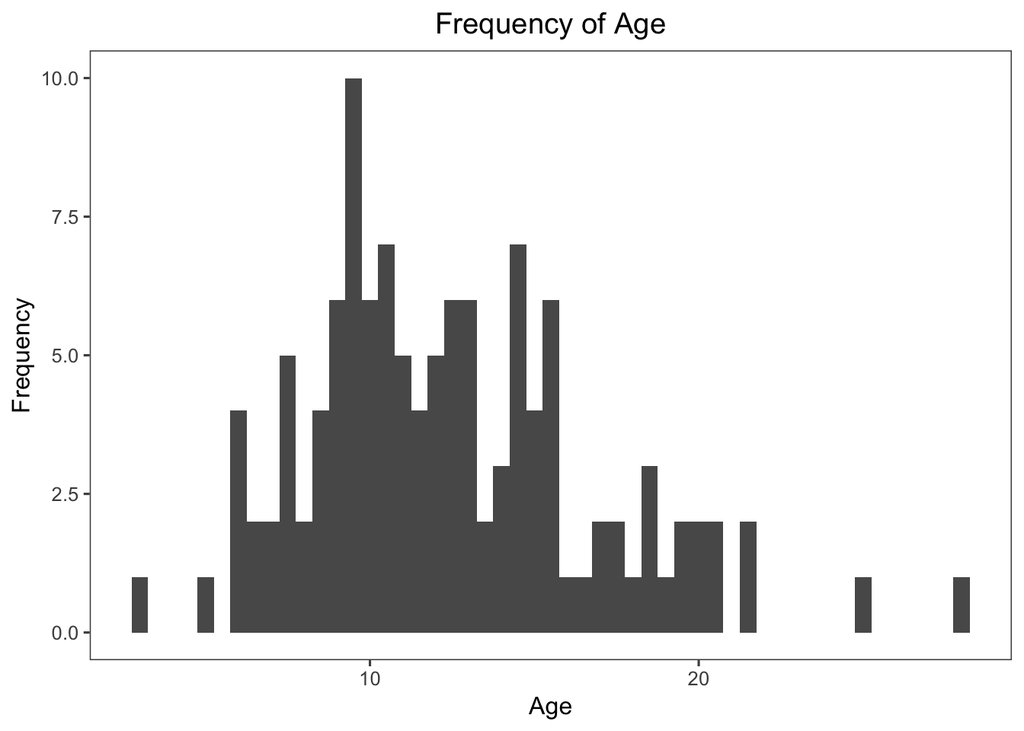

```r
ggplot(justAge, aes(x=age)) +
  geom_histogram(binwidth = .5)+
  ggtitle("Frequency of Age")+ #Add title
  theme(plot.title = element_text(hjust = 0.5))+ #Center title
  xlab("Age")+ #Add x label
  ylab("Frequency") #Add y label
```

Second, make a scatter plot showing the difference in hand looking by age and condition. Add appropriate smoothing lines. Take the time to fix the axis labels and make the plot look nice.

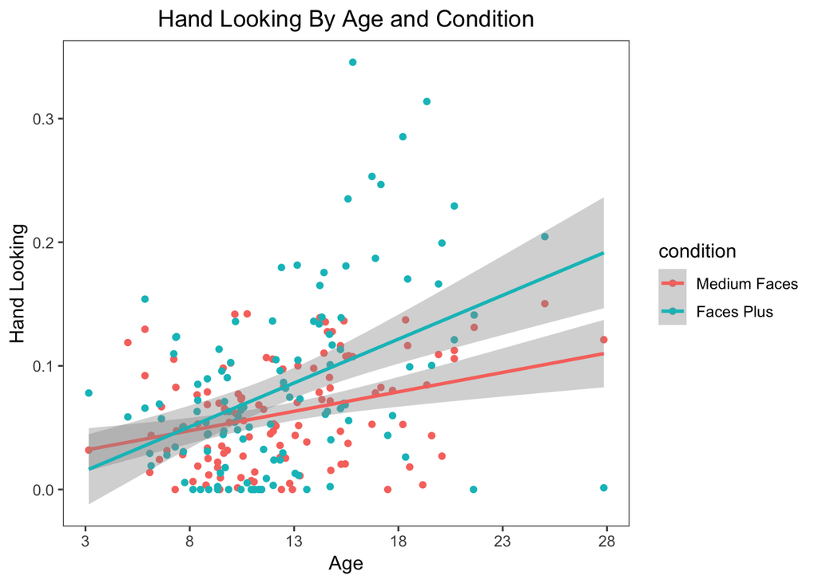

```r
ggplot(fvs, aes(x=age, y=hand.look, colour=condition)) +
  geom_point()+
  geom_smooth(method='lm')+ #Add smoothing lines
  ggtitle("Hand Looking By Age and Condition")+ #Add title
  theme(plot.title = element_text(hjust = 0.5))+ #Center title
  xlab("Age")+ #Add x label
  ylab("Hand Looking")+ #Add y label
  scale_color_hue(labels = c("Medium Faces", "Faces Plus"))+ #Rename key
  scale_x_continuous(breaks = round(seq(min(fvs$age), max(fvs$age+1), by = 5))) #Fix x axis tick marks
```

What do you conclude from this pattern of data?

What statistical analyses would you perform here to quantify these differences?

> I would conduct a linear regression since we have a continuous IV (age), categorical IV (condition) and continuous and ratio-level DV (looking time). I would enter age, condition, and age*condition as predictors of looking time.

# Part 2

Sklar et al. (2012) claim evidence for unconscious arithmetic processing - they prime participants with arithmetic problems and claim that the authors are faster to repeat the answers. We’re going to do a reanalysis of their Experiment 6, which is the primary piece of evidence for that claim. The data are generously shared by Asael Sklar. (You may recall these data from the `tidyverse` tutorial earlier in the quarter).

## Data Prep

First read in two data files and subject info. A and B refer to different trial order counterbalances.

```r
subinfo <- read_csv("data/sklar_expt6_subinfo_corrected.csv")
d_a <- read_csv("data/sklar_expt6a_corrected.csv")
d_b <- read_csv("data/sklar_expt6b_corrected.csv")
```

`gather` these datasets into long (“tidy data”) form. If you need to review tidying, [here’s the link to R4DS](http://r4ds.had.co.nz/tidy-data.html) (bookmark it!). Remember that you can use `select_helpers` to help in your `gather`ing.

Once you’ve tidied, bind all the data together. Check out `bind_rows`.

The resulting tidy dataset should look like this:

```
    prime prime.result target congruent operand distance counterbalance subid    rt
    <chr>        <int>  <int>     <chr>   <chr>    <int>          <int> <dbl> <int>
 1 =1+2+5            8      9        no       A       -1              1     1   597
 2 =1+3+5            9     11        no       A       -2              1     1   699
 3 =1+4+3            8     12        no       A       -4              1     1   700
 4 =1+6+3           10     12        no       A       -2              1     1   628
 5 =1+9+2           12     11        no       A        1              1     1   768
 6 =1+9+3           13     12        no       A        1              1     1   595
```

```r
tidyDataA <- gather(d_a,subid,rt,"1":"21")
tidyDataB <- gather(d_b,subid,rt,"22":"42")

d_tidy <- bind_rows(tidyDataA, tidyDataB)
```

Merge these with subject info. You will need to look into merge and its relatives, `left_` and `right_join`. Call this dataframe `d`, by convention.

```r
d_tidy$subid <- as.numeric(d_tidy$subid)
subinfo$subid <- as.numeric(subinfo$subid)

d <- right_join(d_tidy, subinfo, by="subid")
```

Clean up the factor structure (just to make life easier). No need to, but if you want, you can make this more `tidyverse`-ish.

```r
d$presentation.time <- factor(d$presentation.time)
levels(d$operand) <- c("addition","subtraction")
```

## Data Analysis Preliminaries

Examine the basic properties of the dataset. First, show a histogram of reaction times.

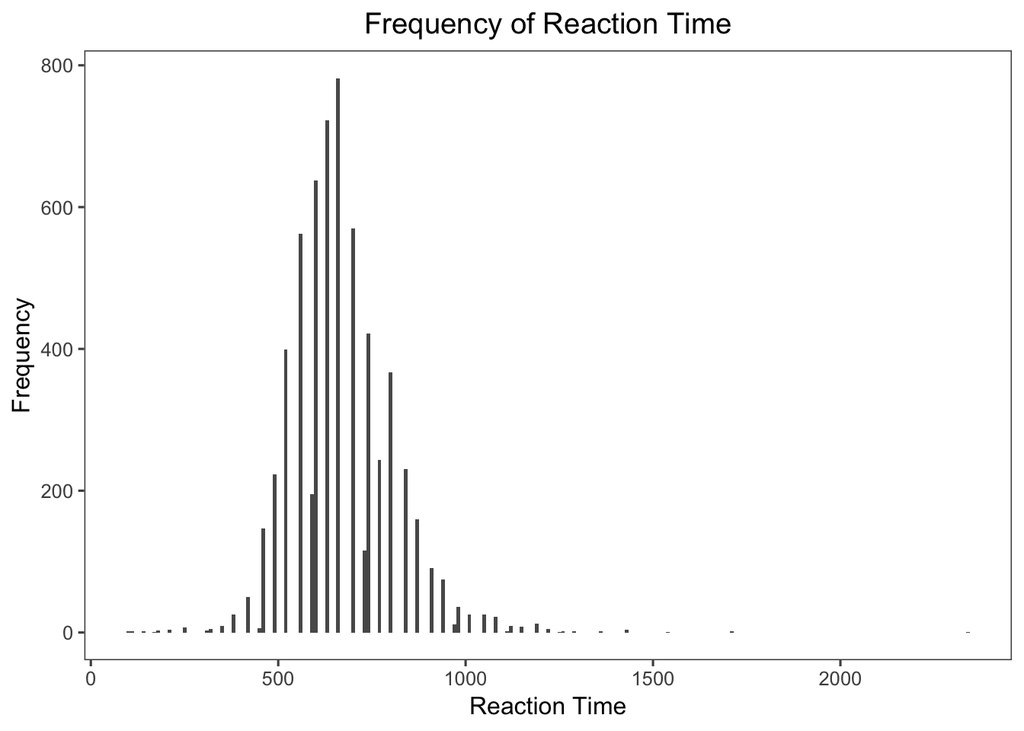

```r
ggplot(d, aes(x=rt))+
  geom_histogram(binwidth = 10)+
  ggtitle("Frequency of Reaction Time")+ #Title plot
  theme(plot.title = element_text(hjust = 0.5))+ #Center title
  xlab("Reaction Time")+ #Add x label
  ylab("Frequency") #Add y label
```

Challenge question: what is the sample rate of the input device they are using to gather RTs?

Sklar et al. did two manipulation checks. Subjective - asking participants whether they saw the primes - and objective - asking them to report the parity of the primes (even or odd) to find out if they could actually read the primes when they tried. Examine both the unconscious and conscious manipulation checks. What do you see? Are they related to one another?

```r
cor.test(d$subjective.test, d$objective.test)
```

```
##
##  Pearson's product-moment correlation
##
## data:  d$subjective.test and d$objective.test
## t = 57.052, df = 6466, p-value < 2.2e-16
## alternative hypothesis: true correlation is not equal to 0
## 95 percent confidence interval:
##  0.5622115 0.5946395
## sample estimates:
##       cor
## 0.5786542
```

> Yes, they are related to one another - the correlation (0.58) is significant (p < 0.00000000000000022). This suggests that participants’ subjective self-reports of having seen the primes were accurate.

> In Experiments 6, 7, and 9, we used the binomial distribution to determine whether each participant performed better than chance on the objective block and excluded from analyses all those participants who did (21, 30, and 7 participants in Experiments 6, 7, and 9, respectively). Note that, although the number of excluded participants may seem high, they fall within the normal range of long-duration CFS priming, in which successful suppression is strongly affected by individual differences (38). We additionally excluded participants who reported any subjective awareness of the primes (four, five, and three participants in Experiments 6, 7, and 9, respectively).

OK, let’s turn back to the measure and implement Sklar et al.’s exclusion criterion. You need to have said you couldn’t see (subjective test) and also be not significantly above chance on the objective test (< .6 correct). Call your new data frame `ds`.

```r
ds <- d %>%
  filter(subjective.test == 0 & objective.test < 0.6) #What to keep
```

## Replicating Sklar et al.’s analysis

Sklar et al. show a plot of a “facilitation effect” - the amount faster you are for prime-congruent naming compared with prime-incongruent naming. They then show plot this difference score for the subtraction condition and for the two prime times they tested. Try to reproduce this analysis.

HINT 2: remember that in class, we reviewed the common need to `group_by` and `summarise` *twice*, the first time to get means for *each subject*, the second time to compute statistics *across subjects*.

HINT 3: The final summary dataset should have 4 rows and 5 columns (2 columns for the two conditions and 3 columns for the outcome: reaction time, ci, and n).

```r
table <- ds %>%
  filter(operand=="S") %>% #Only subtraction operand
  group_by(subid, congruent, presentation.time) %>%
  summarise(sub_rt = mean(rt, na.rm = TRUE)) %>%

  group_by(congruent, presentation.time) %>%
  summarise(`reaction time` = mean(sub_rt), ci = ci(sub_rt), n=n())

table
```

```
## # A tibble: 4 x 5
## # Groups:   congruent [?]
##   congruent presentation.time `reaction time`    ci     n
##   <chr>     <fct>                       <dbl> <dbl> <int>
## 1 no        1700                         718.  78.6     8
## 2 no        2000                         641.  68.2     9
## 3 yes       1700                         697.  71.4     8
## 4 yes       2000                         631.  71.6     9
```

Now plot this summary, giving more or less the bar plot that Sklar et al. gave (though I would keep operation as a variable here. Make sure you get some error bars on there (e.g. `geom_errorbar` or `geom_linerange`).

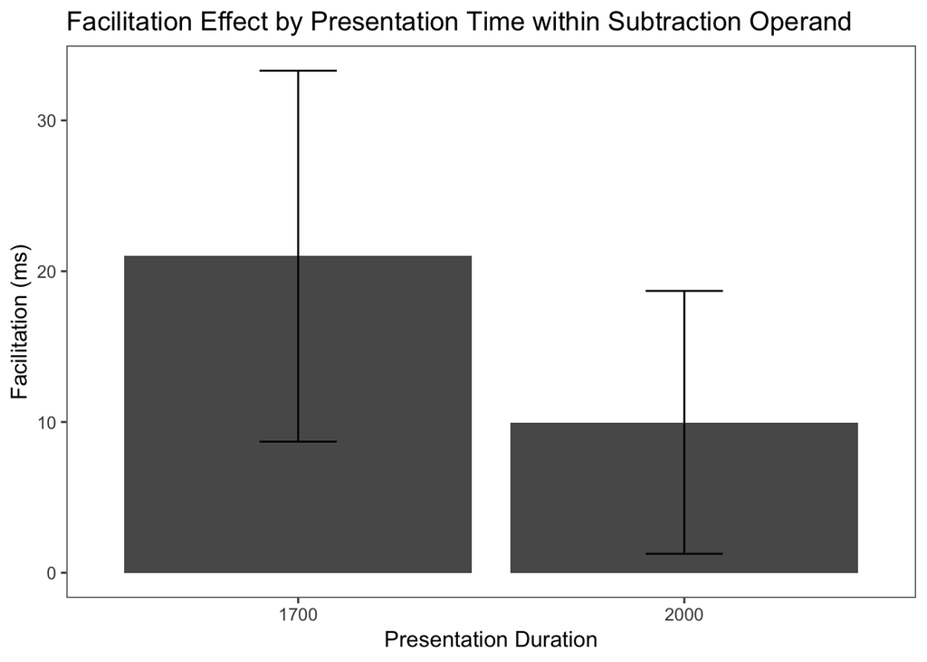

```r
#Create new table (to include difference score between congruent and incongruent)
forPlot <- ds %>%
  filter(operand =="S") %>% #Only subtraction operand
  group_by(subid, congruent, presentation.time) %>%
  summarize(`reaction time` = mean(rt, na.rm  = TRUE)) %>%
  spread(congruent, `reaction time`) %>%
  mutate(diff = no - yes) %>%
  group_by(presentation.time) %>%
  summarise(facilitation = mean(diff), ci = ci(diff))

#Recreate Sklar et al. plot
p <- ggplot(data=forPlot, aes(x=presentation.time, y=facilitation)) +
  geom_bar(position = "dodge", stat="identity")+
  ggtitle("Facilitation Effect by Presentation Time within Subtraction Operand")+
  xlab("Presentation Duration")+
  ylab("Facilitation (ms)")+
  geom_errorbar(aes(ymin=facilitation-ci, ymax=facilitation+ci), width=.2, position=position_dodge(.9))

p
```

What do you see here? How close is it to what Sklar et al. report? How do you interpret these data?

> The means of the two presentation durations (1700 and 2000) are the same, but the error bars are not (theirs are much shorter). It seems from looking at our largely overlapping error bars that there is actually no sig difference in the facilitation effect between the two presentation durations.